# Exploratory Data Analysis

## 4. Seasonal PM2.5 Comparison (Faceted)

Compare summer vs winter PM2.5 levels across boroughs.

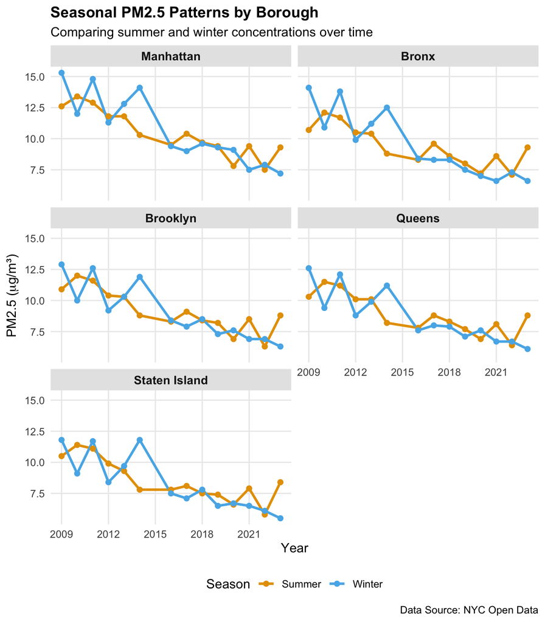

```r
ggplot(df_long %>% filter(pm25_type != "Annual"),
       aes(x = year, y = pm25_value, color = pm25_type)) +
  geom_line(linewidth = 1.1) +
  geom_point(size = 2) +
  facet_wrap(~ borough, ncol = 2) +
  scale_color_manual(values = c("Summer" = "#E69F00", "Winter" = "#56B4E9")) +
  scale_x_continuous(breaks = seq(2009, 2023, 3)) +
  labs(
    title = "Seasonal PM2.5 Patterns by Borough",
    subtitle = "Comparing summer and winter concentrations over time",
    x = "Year",
    y = expression("PM2.5 ("*mu*"g/m³)"),
    color = "Season",
    caption = "Data Source: NYC Open Data"
  ) +
  theme_minimal(base_size = 12) +
  theme(
    plot.title = element_text(face = "bold", size = 14),
    strip.text = element_text(face = "bold", size = 11),
    strip.background = element_rect(fill = "gray90", color = NA),
    legend.position = "bottom",
    panel.grid.minor = element_blank()
  )
```

## 5. Borough Comparison Summary (Side-by-Side)

Direct comparison of all boroughs on the same plot.

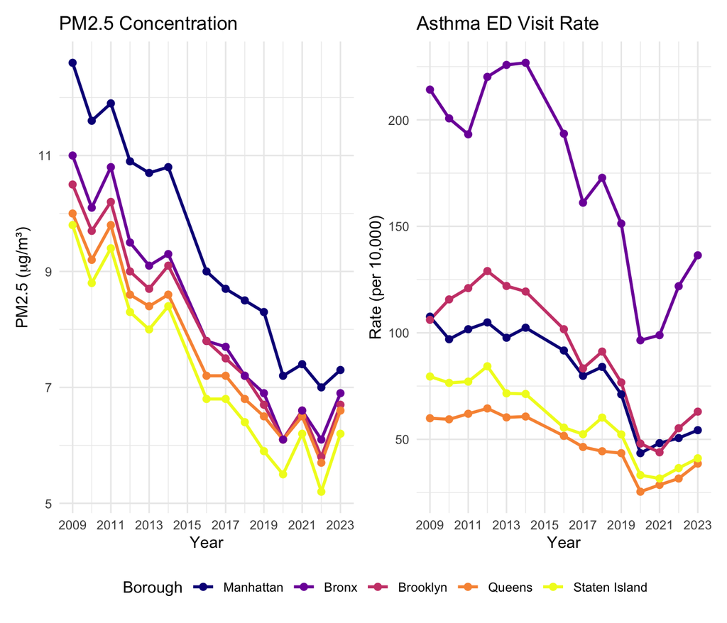

```r
p1 <- ggplot(df, aes(x = year, y = pm25_annual, color = borough)) +
  geom_line(linewidth = 1) +
  geom_point(size = 2) +
  scale_color_viridis_d(option = "plasma") +
  scale_x_continuous(breaks = seq(2009, 2023, 2)) +
  labs(
    title = "PM2.5 Concentration",
    x = "Year",
    y = expression("PM2.5 ("*mu*"g/m³)"),
    color = "Borough"
  ) +
  theme_minimal() +
  theme(legend.position = "bottom")

p2 <- ggplot(df, aes(x = year, y = asthma_rate, color = borough)) +
  geom_line(linewidth = 1) +
  geom_point(size = 2) +
  scale_color_viridis_d(option = "plasma") +
  scale_x_continuous(breaks = seq(2009, 2023, 2)) +
  labs(
    title = "Asthma ED Visit Rate",
    x = "Year",
    y = "Rate (per 10,000)",
    color = "Borough"
  ) +
  theme_minimal() +
  theme(legend.position = "bottom")

p1 + p2 + plot_layout(guides = "collect") & theme(legend.position = "bottom")
```

# Heatmaps (Year × Borough)

Since the data is annual (not monthly), we’ll create year × borough heatmaps to visualize patterns.

## 1. PM2.5 Annual Concentration Heatmap

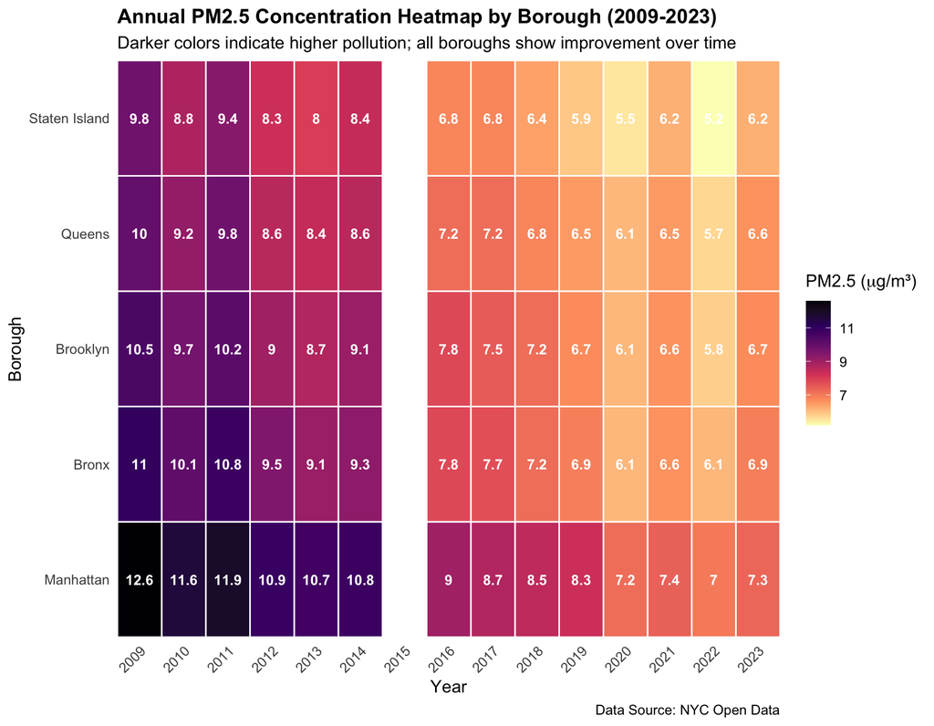

```r
ggplot(df, aes(x = year, y = borough, fill = pm25_annual)) +
  geom_tile(color = "white", linewidth = 0.5) +
  geom_text(aes(label = round(pm25_annual, 1)), color = "white", size = 3.5, fontface = "bold") +
  scale_fill_viridis_c(option = "magma", direction = -1,
                       name = expression("PM2.5 ("*mu*"g/m³)")) +
  scale_x_continuous(breaks = 2009:2023, expand = c(0, 0)) +
  scale_y_discrete(expand = c(0, 0)) +
  labs(
    title = "Annual PM2.5 Concentration Heatmap by Borough (2009-2023)",
    subtitle = "Darker colors indicate higher pollution; all boroughs show improvement over time",
    x = "Year",
    y = "Borough",
    caption = "Data Source: NYC Open Data"
  ) +
  theme_minimal(base_size = 12) +
  theme(
    plot.title = element_text(face = "bold", size = 14),
    axis.text.x = element_text(angle = 45, hjust = 1),
    panel.grid = element_blank(),
    legend.position = "right"
  )
```

## 2. Asthma ED Visit Rate Heatmap

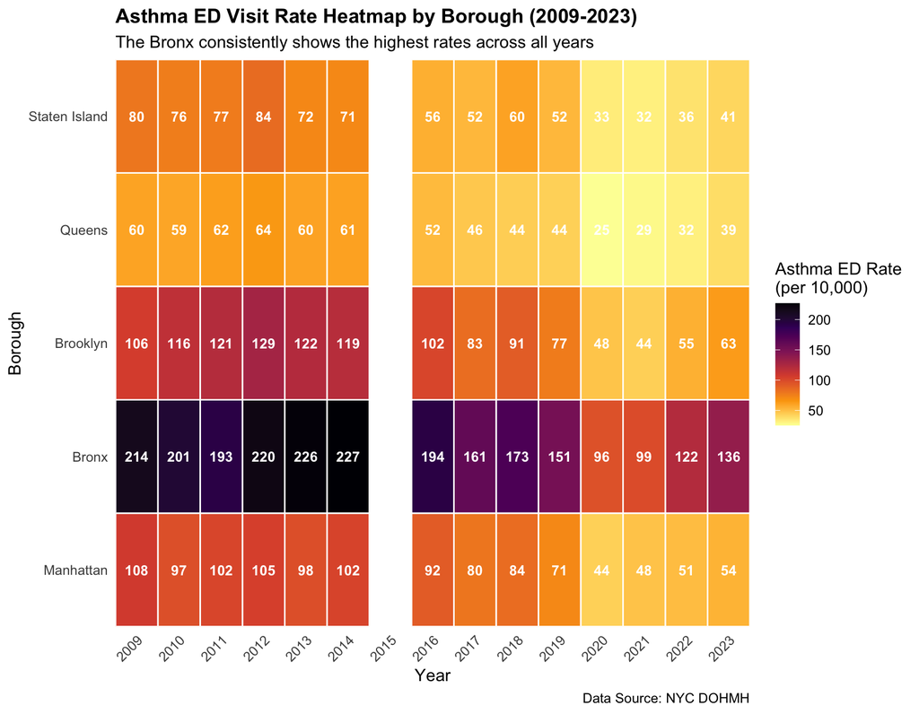

```r
ggplot(df, aes(x = year, y = borough, fill = asthma_rate)) +
  geom_tile(color = "white", linewidth = 0.5) +
  geom_text(aes(label = round(asthma_rate, 0)), color = "white", size = 3.5, fontface = "bold") +
  scale_fill_viridis_c(option = "inferno", direction = -1,
                       name = "Asthma ED Rate\n(per 10,000)") +
  scale_x_continuous(breaks = 2009:2023, expand = c(0, 0)) +
  scale_y_discrete(expand = c(0, 0)) +
  labs(
    title = "Asthma ED Visit Rate Heatmap by Borough (2009-2023)",
    subtitle = "The Bronx consistently shows the highest rates across all years",
    x = "Year",
    y = "Borough",
    caption = "Data Source: NYC DOHMH"
  ) +
  theme_minimal(base_size = 12) +
  theme(
    plot.title = element_text(face = "bold", size = 14),
    axis.text.x = element_text(angle = 45, hjust = 1),
    panel.grid = element_blank(),
    legend.position = "right"
  )
```

## 3. Summer PM2.5 Heatmap

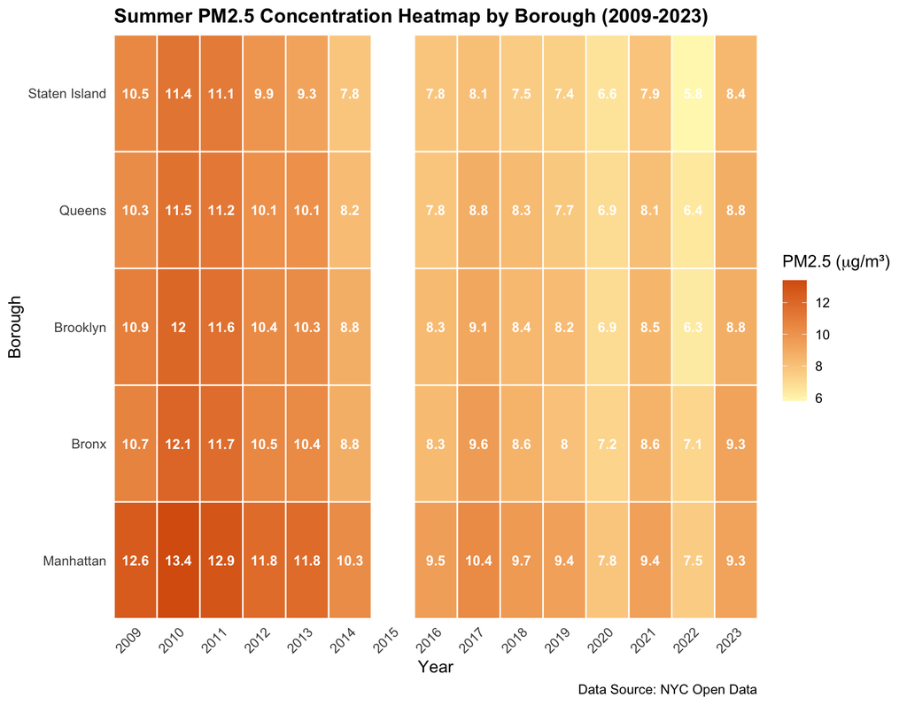

```r
ggplot(df, aes(x = year, y = borough, fill = pm25_summer)) +
  geom_tile(color = "white", linewidth = 0.5) +
  geom_text(aes(label = round(pm25_summer, 1)), color = "white", size = 3.5, fontface = "bold") +
  scale_fill_gradient(low = "#FFF7BC", high = "#D95F0E",
                      name = expression("PM2.5 ("*mu*"g/m³)")) +
  scale_x_continuous(breaks = 2009:2023, expand = c(0, 0)) +
  scale_y_discrete(expand = c(0, 0)) +
  labs(
    title = "Summer PM2.5 Concentration Heatmap by Borough (2009-2023)",
    x = "Year",
    y = "Borough",
    caption = "Data Source: NYC Open Data"
  ) +
  theme_minimal(base_size = 12) +
  theme(
    plot.title = element_text(face = "bold", size = 14),
    axis.text.x = element_text(angle = 45, hjust = 1),
    panel.grid = element_blank()
  )
```

## 4. Winter PM2.5 Heatmap

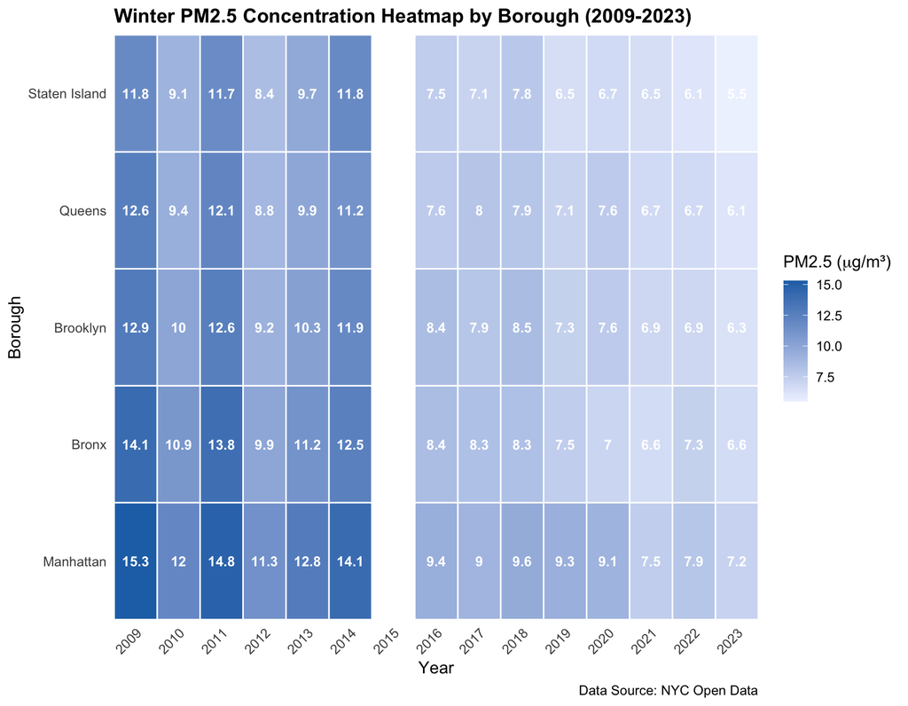

```r
ggplot(df, aes(x = year, y = borough, fill = pm25_winter)) +
  geom_tile(color = "white", linewidth = 0.5) +
  geom_text(aes(label = round(pm25_winter, 1)), color = "white", size = 3.5, fontface = "bold") +
  scale_fill_gradient(low = "#EFF3FF", high = "#2171B5",
                      name = expression("PM2.5 ("*mu*"g/m³)")) +
  scale_x_continuous(breaks = 2009:2023, expand = c(0, 0)) +
  scale_y_discrete(expand = c(0, 0)) +
  labs(
    title = "Winter PM2.5 Concentration Heatmap by Borough (2009-2023)",
    x = "Year",
    y = "Borough",
    caption = "Data Source: NYC Open Data"
  ) +
  theme_minimal(base_size = 12) +
  theme(
    plot.title = element_text(face = "bold", size = 14),
    axis.text.x = element_text(angle = 45, hjust = 1),
    panel.grid = element_blank()
  )
```

## 5. Seasonal Difference Heatmap (Winter - Summer)

This shows which borough-years had higher winter vs summer pollution.

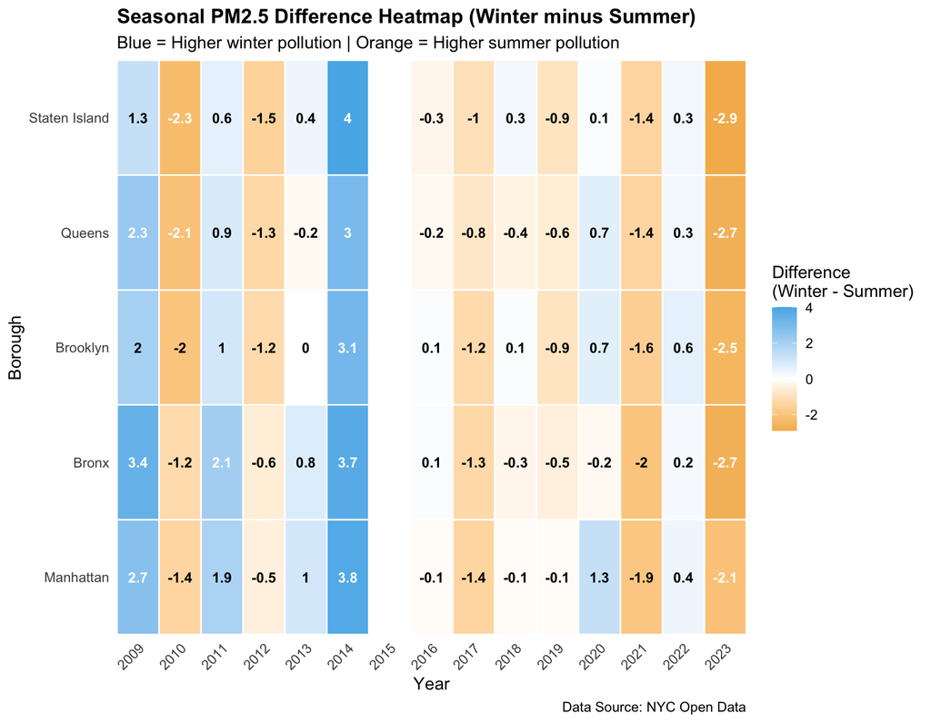

```r
df <- df %>%
  mutate(pm25_diff = pm25_winter - pm25_summer)

ggplot(df, aes(x = year, y = borough, fill = pm25_diff)) +
  geom_tile(color = "white", linewidth = 0.5) +
  geom_text(aes(label = round(pm25_diff, 1)),
            color = ifelse(abs(df$pm25_diff) > 2, "white", "black"),
            size = 3.5, fontface = "bold") +
  scale_fill_gradient2(low = "#E69F00", mid = "white", high = "#56B4E9",
                       midpoint = 0,
                       name = "Difference\n(Winter - Summer)") +
  scale_x_continuous(breaks = 2009:2023, expand = c(0, 0)) +
  scale_y_discrete(expand = c(0, 0)) +
  labs(
    title = "Seasonal PM2.5 Difference Heatmap (Winter minus Summer)",
    subtitle = "Blue = Higher winter pollution | Orange = Higher summer pollution",
    x = "Year",
    y = "Borough",
    caption = "Data Source: NYC Open Data"
  ) +
  theme_minimal(base_size = 12) +
  theme(
    plot.title = element_text(face = "bold", size = 14),
    axis.text.x = element_text(angle = 45, hjust = 1),
    panel.grid = element_blank()
  )
```

# Key Findings

## Borough Disparities

```r
# Calculate summary statistics by borough
borough_summary <- df %>%
  group_by(borough) %>%
  summarise(
    mean_pm25 = mean(pm25_annual, na.rm = TRUE),
    mean_asthma = mean(asthma_rate, na.rm = TRUE),
    pm25_2023 = pm25_annual[year == 2023],
    asthma_2023 = asthma_rate[year == 2023],
    pm25_change = pm25_annual[year == 2023] - pm25_annual[year == 2009],
    asthma_change = asthma_rate[year == 2023] - asthma_rate[year == 2009]
  ) %>%
  arrange(desc(mean_asthma))

knitr::kable(borough_summary,
             digits = 1,
             col.names = c("Borough", "Avg PM2.5", "Avg Asthma Rate",
                          "PM2.5 (2023)", "Asthma (2023)",
                          "PM2.5 Change", "Asthma Change"),
             caption = "Borough Summary Statistics (2009-2023)")
```

Borough Summary Statistics (2009-2023)

| Borough | Avg PM2.5 | Avg Asthma Rate | PM2.5 (2023) | Asthma (2023) | PM2.5 Change | Asthma Change |
| --- | --- | --- | --- | --- | --- | --- |
| Bronx | 8.2 | 172.4 | 6.9 | 136.4 | -4.1 | -77.8 |
| Brooklyn | 8.0 | 91.2 | 6.7 | 63.0 | -3.8 | -43.1 |
| Manhattan | 9.4 | 81.0 | 7.3 | 54.3 | -5.3 | -53.3 |
| Staten Island | 7.3 | 58.8 | 6.2 | 41.1 | -3.6 | -38.4 |
| Queens | 7.7 | 48.4 | 6.6 | 38.6 | -3.4 | -21.3 |

## Conclusions

1. **Bronx Health Disparity**: The Bronx consistently shows the highest asthma ED visit rates across all years, roughly 2-4 times higher than other boroughs.
2. **Air Quality Improvement**: All boroughs have experienced substantial reductions in PM2.5 concentrations since 2009, with Manhattan showing the largest absolute decrease.
3. **Positive Correlation**: Higher PM2.5 levels are generally associated with higher asthma ED visit rates, though borough-specific factors also play important roles.
4. **Seasonal Variation**: Winter PM2.5 levels were historically higher than summer, but this pattern has shifted in recent years.